# US Unemployment Rates

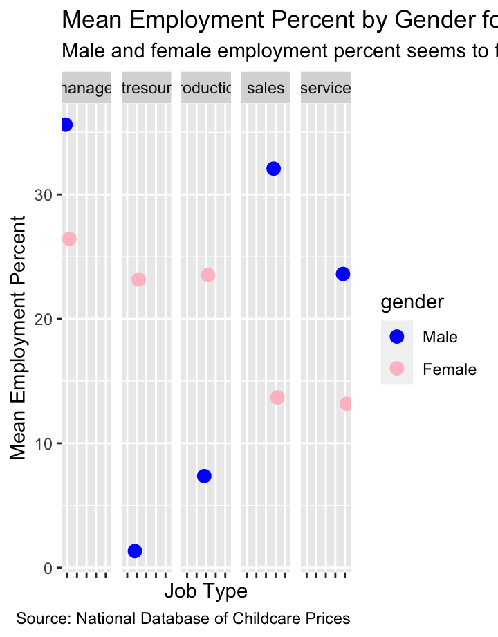

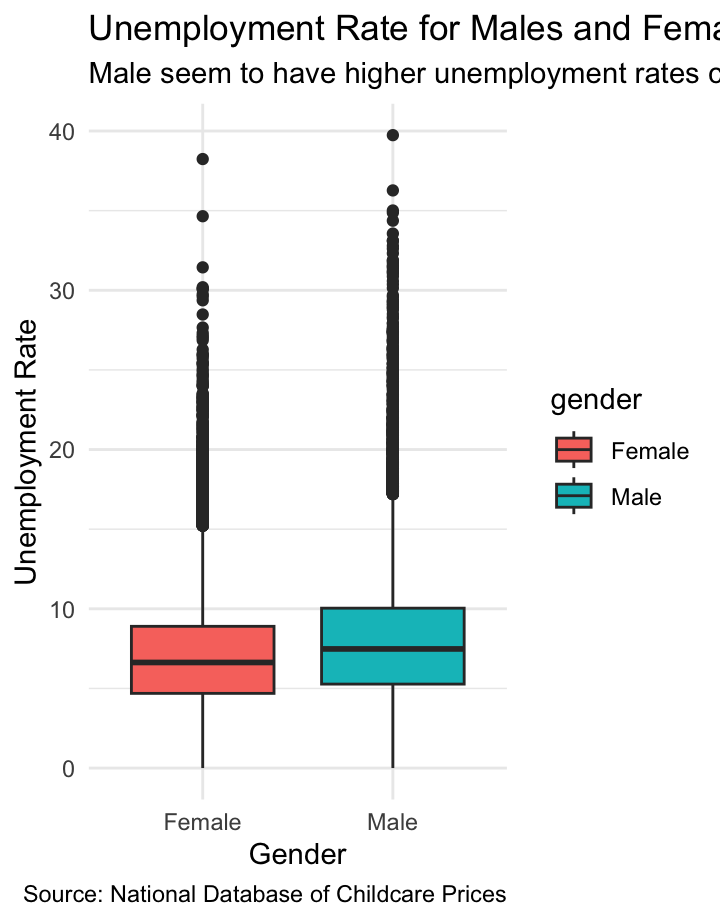

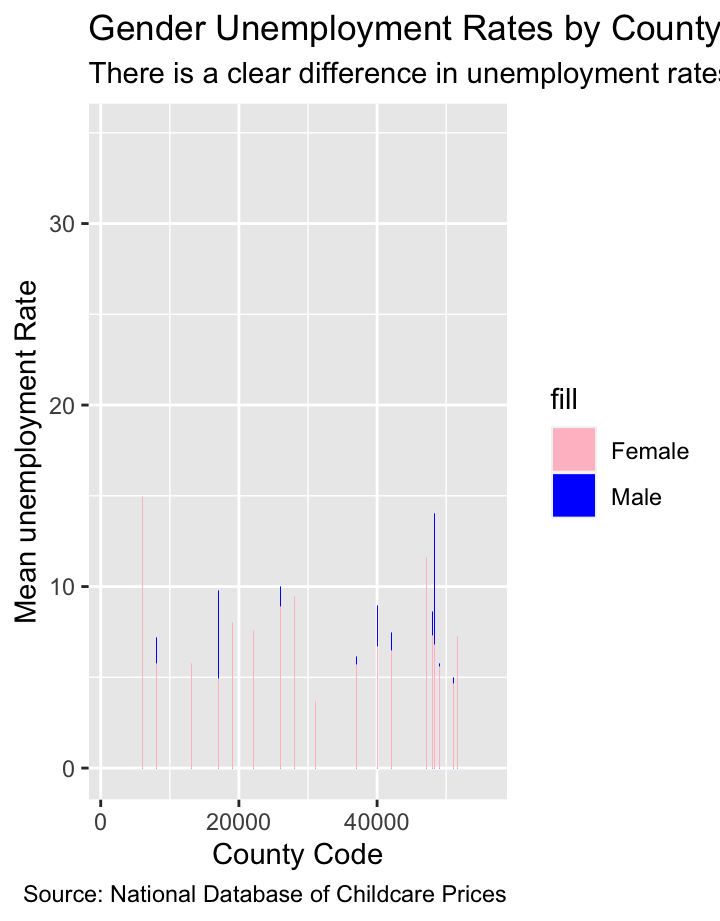

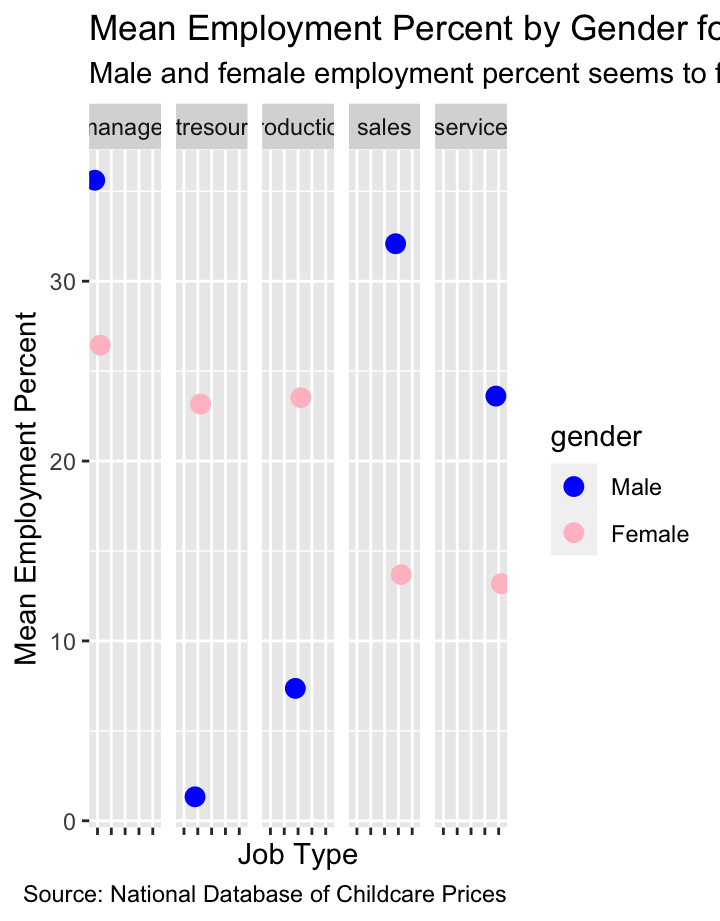

# About

**Purpose** The purpose of this dashboard is to bring awareness to employment rate differences by gender.

**Original Source**

This dataset was analyzed for project 2 of this course. Found in the [Tidy Tuesday GitHub repository](https://github.com/rfordatascience/tidytuesday), this data set comes from [the National Database of Childcare Prices](https://www.dol.gov/agencies/wb/topics/featured-childcare). For more information on this data set, reference the linked article [here](https://www.dol.gov/sites/dolgov/files/WB/NDCP/508_WB_IssueBrief-NDCP-20230213.pdf)

### Figure

This figure shows prior research which made me interested in the project and motivated my topic choice.

The figure link and source is from an article I read [here](https://www.motherjones.com/kevin-drum/2020/10/black-white-men-women-a-deeper-look-at-the-employment-numbers/)

[figure not shown]

# The Data

### Loading the Data

```r
if (!dir.exists(here("data"))) {
  dir.create(here("data"))
}
childcare_costs_data <- here("data", "childcare_costs.csv")

childcare_costs <- readr::read_csv('https://raw.githubusercontent.com/rfordatascience/tidytuesday/master/data/2023/2023-05-09/childcare_costs.csv', show_col_types = FALSE)
readr::write_csv(childcare_costs, childcare_costs_data)
```

### Data Dictionary

**Data Dictionary**

The data dictionary for `childcare_costs.csv`[here](https://github.com/rfordatascience/tidytuesday/blob/master/data/2023/2023-05-09/readme.md).

These are the specific variables I use in my analysis.

|  | variable_name | value |
| --- | --- | --- |
| 1 | county_fips_code | Four- or five-digit number that uniquely identifies the county in a state. The first two digits (for five-digit numbers) or 1 digit (for four-digit numbers) refer to the FIPS code of the state to whic… |
| 2 | funr_16 | Unemployment rate of the female population aged 16 years old or older. |
| 3 | munr_16 | Unemployment rate of the male population aged 16 years old or older. |
| 4 | memp_m | Percent of male civilians employed in management, business, science, and arts occupations aged 16 years old or older in the county. |
| 5 | femp_m | Percent of female civilians employed in management, business, science, and arts occupations aged 16 years old or older in the county. |
| 6 | memp_service | Percent of male civilians employed in service occupations aged 16 years old and older in the county. |
| 7 | femp_service | Percent of female civilians employed in service occupations aged 16 years old and older in the county. |
| 8 | memp_sales | Percent of male civilians employed in sales and office occupations aged 16 years old and older in the county. |
| 9 | femp_sales | Percent of female civilians employed in sales and office occupations aged 16 years old and older in the county. |
| 10 | memp_n | Percent of male civilians employed in natural resources, construction, and maintenance occupations aged 16 years old and older in the county. |

[output cut: 3 more lines]

### Data (variables) Summary Table

```
 county_fips_code   study_year       unr_16          funr_16
 Min.   : 1001    Min.   :2008   Min.   : 0.000   Min.   : 0.000
 1st Qu.:18177    1st Qu.:2010   1st Qu.: 5.100   1st Qu.: 4.640
 Median :29177    Median :2013   Median : 7.050   Median : 6.590
 Mean   :30388    Mean   :2013   Mean   : 7.466   Mean   : 7.029
 3rd Qu.:45081    3rd Qu.:2016   3rd Qu.: 9.350   3rd Qu.: 8.880
 Max.   :56045    Max.   :2018   Max.   :36.110   Max.   :38.240

    munr_16        unr_20to64    funr_20to64      munr_20to64
 Min.   : 0.00   Min.   : 0.0   Min.   : 0.000   Min.   : 0.000
 1st Qu.: 5.20   1st Qu.: 4.6   1st Qu.: 4.200   1st Qu.: 4.700
 Median : 7.39   Median : 6.5   Median : 6.000   Median : 6.800
 Mean   : 7.86   Mean   : 6.9   Mean   : 6.482   Mean   : 7.275
 3rd Qu.: 9.92   3rd Qu.: 8.7   3rd Qu.: 8.250   3rd Qu.: 9.200
 Max.   :39.74   Max.   :33.9   Max.   :44.500   Max.   :45.500

  flfpr_20to64    flfpr_20to64_under6 flfpr_20to64_6to17
 Min.   : 33.60   Min.   :  0.00      Min.   :  0.00
 1st Qu.: 65.10   1st Qu.: 62.60      1st Qu.: 74.40
 Median : 70.60   Median : 69.60      Median : 79.45
 Mean   : 70.09   Mean   : 68.82      Mean   : 78.82
 3rd Qu.: 75.50   3rd Qu.: 76.10      3rd Qu.: 84.22
 Max.   :100.00   Max.   :100.00      Max.   :100.00

 flfpr_20to64_under6_6to17  mlfpr_20to64         pr_f            pr_p
 Min.   :  0.00            Min.   :  8.20   Min.   : 0.00   Min.   : 0.00
 1st Qu.: 59.80            1st Qu.: 74.20   1st Qu.: 7.70   1st Qu.:11.40
 Median : 67.66            Median : 81.00   Median :10.90   Median :15.20
 Mean   : 66.94            Mean   : 78.64   Mean   :11.74   Mean   :16.04
 3rd Qu.: 75.20            3rd Qu.: 85.90   3rd Qu.:14.60   3rd Qu.:19.50
 Max.   :100.00            Max.   :100.00   Max.   :52.10   Max.   :55.10

    mhi_2018         me_2018         fme_2018        mme_2018
 Min.   : 19842   Min.   : 4947   Min.   : 5019   Min.   : 4238
 1st Qu.: 41839   1st Qu.:25955   1st Qu.:20613   1st Qu.:31448
 Median : 48506   Median :28654   Median :22855   Median :35103
 Mean   : 50447   Mean   :29404   Mean   :23475   Mean   :35997
 3rd Qu.: 56201   3rd Qu.:32006   3rd Qu.:25635   3rd Qu.:39503
 Max.   :136268   Max.   :70565   Max.   :68600   Max.   :98580

```

[output cut: 73 more lines]

```
 Min.   : 27.73   Min.   : 21.54   Min.   : 21.54   Min.   : 43.08
 1st Qu.:108.75   1st Qu.:100.00   1st Qu.: 95.88   1st Qu.: 90.00
 Median :134.50   Median :120.99   Median :113.99   Median :106.00
 Mean   :146.05   Mean   :130.48   Mean   :122.23   Mean   :113.42
 3rd Qu.:166.33   3rd Qu.:148.71   3rd Qu.:139.30   3rd Qu.:129.31
 Max.   :470.00   Max.   :419.00   Max.   :385.00   Max.   :430.94
 NA's   :10974    NA's   :10974    NA's   :10974    NA's   :11184
  mfcc_toddler    mfcc_preschool
 Min.   : 43.08   Min.   : 40.03
 1st Qu.: 85.08   1st Qu.: 84.25
 Median :100.25   Median : 99.65
 Mean   :106.76   Mean   :104.19
 3rd Qu.:124.95   3rd Qu.:120.20
 Max.   :376.32   Max.   :331.34
 NA's   :11184    NA's   :11184
```

# Data Analysis

### Questions

Question 1: How do overall unemployment rates for individuals 16 or older vary by gender?

Question 2: How does this unemployment by gender vary by region?

Question 3: Do certain employment types for individuals 16 and older have higher percentages employed of males compared to females?

### Code

#### Question 1

```r
childcare_costs <- na.omit(childcare_costs)
plot1<- childcare_costs %>% select(funr_16, munr_16) %>%
  pivot_longer(cols = c(munr_16, funr_16), names_to = "gender", values_to = "unemployment_rate") %>%
  mutate(gender = ifelse(gender == "munr_16", "Male", "Female")) %>% #all munr_16 is male, else is female
  ggplot(aes(x = gender, y = unemployment_rate, fill = gender)) +
  geom_boxplot() +
  labs(title = "Unemployment Rate for Males and Females 16 and Older",
       subtitle = "Male seem to have higher unemployment rates compared to females",
       x = "Gender",
       y = "Unemployment Rate",
       caption = "Source: National Database of Childcare Prices") +
  theme_minimal()
```

#### Question 2

```r
# Part 1
plot2<-childcare_costs %>%
  select(county_fips_code, munr_16, funr_16) %>%
  group_by(county_fips_code) %>%
  summarize(male = mean(munr_16),
            female = mean(funr_16)) %>%
  ggplot(aes(x = county_fips_code)) +
  geom_bar(aes(y = male, fill = "Male"), position = "dodge", stat = "identity") +
  geom_bar(aes(y = female, fill = "Female"), position = "dodge", stat = "identity") +
  labs(title = "Gender Unemployment Rates by County Codes",
       subtitle = "There is a clear difference in unemployment rates for sex depending on county ",
       x = "County Code",
       y = "Mean unemployment Rate",
       caption = "Source: National Database of Childcare Prices") +
  scale_fill_manual(values = c("Male" = "blue", "Female" = "pink"))

# Part 2
childcare_costs$munr_16<- make_ci_class(childcare_costs$munr_16)
childcare_costs$funr_16<- make_ci_class(childcare_costs$funr_16)


# Counties with lowest unemployment rate for males
childcare_costs_male_low<- childcare_costs %>%
  select(county_fips_code, munr_16, funr_16) %>% filter(munr_16<1)
v1<- cat("Counties with lowest unemployment rates for males", calculate_CI(childcare_costs_male_low$munr_16, conf = 0.95))


# Counties with lowest unemployment rate for females
childcare_costs_female_low<- childcare_costs %>%
  select(county_fips_code, munr_16, funr_16) %>% filter(funr_16<1)
v2<- cat("Counties with lowest unemployment rates for females",calculate_CI(childcare_costs_female_low$munr_16, conf = 0.95))

# Counties with highest unemploymet rates for males
childcare_costs_male_high<- childcare_costs %>%
  select(county_fips_code, munr_16, funr_16) %>% filter(munr_16>20)
v3<- cat("Counties with highest unemployment rates for males", calculate_CI(childcare_costs_male_high$munr_16, conf = 0.95))

# Counties with highest unemploymet rates for females
childcare_costs_female_high<- childcare_costs %>%
  select(county_fips_code, munr_16, funr_16) %>% filter(funr_16>18)
v4<-cat("Counties with highest unemployment rates for females", calculate_CI(childcare_costs_female_high$funr_16, conf = 0.95)) #lower threshold to get approximately the same amount as males
```

#### Question 3

[figure not shown]

```r
# Sorry for the long renaming, but I did this so I can easily split (using separate) gender and job type later to get the table I wanted before using ggplot
childcare_costs %>%
  rename(m_manager = memp_m,f_manager = femp_m,m_service = memp_service,f_service = femp_service,m_sales = memp_sales,f_sales = femp_sales,m_natresource = memp_n,f_natresource = femp_n,m_production = memp_p,f_production = femp_p) %>%
  select(m_manager, f_manager, m_service, f_service, m_sales, f_sales, m_natresource, f_natresource, m_production, f_production) %>%
  summarise(across(everything(), ~mean(., na.rm = TRUE))) %>% #so I don't have to write out mean for each one
  pivot_longer(cols = everything(), names_to = "job_type", values_to = "mean") %>%
  separate(job_type, into = c("gender", "job"), sep = "_") %>% #categorize so the job type and gender is sep cols so that I can get a graph with both genders separated by job type
  ggplot(aes(x = job, y = mean, color = gender)) +
  geom_point(position = position_dodge(width = 0.8), size = 3) +
  facet_grid(~job) +
  labs(title = "Mean Employment Percent by Gender for Each Job Type",
       subtitle = "Male and female employment percent seems to fluctuate by employment type",
       x = "Job Type",
       y = "Mean Employment Percent",
       caption = "Source: National Database of Childcare Prices") +
  scale_color_manual(values = c("blue", "pink"), labels = c("Male", "Female"))+
  theme(axis.text.x = element_blank()) #I purposefully wanted to remove this bc it is cluttery and facet labels already does this anyways
```

# Male vs Female Unemployment (16+)

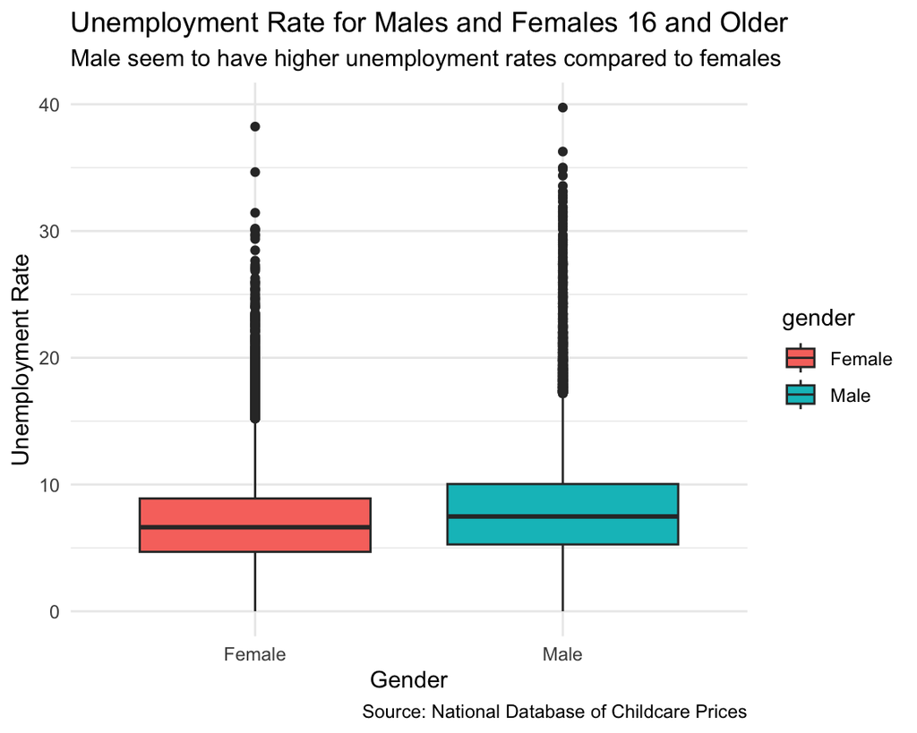

# Unemployment by County (Visual)

### Part 1

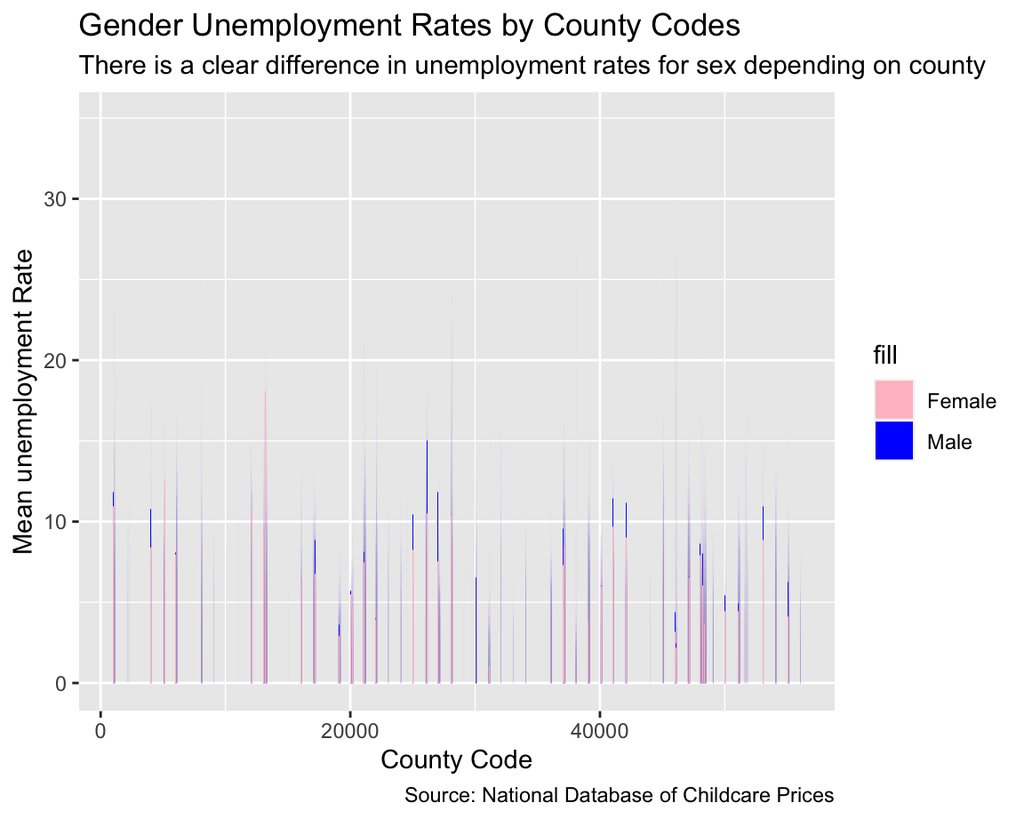

### Unemployment By County (Quantitative)

```
Counties with lowest unemployment rates for males 0.4148901 0.4862299
```

[output not shown]

```
Counties with highest unemployment rates for males 23.49313 24.34666
```

```
Counties with highest unemployment rates for females 20.53419 21.30961
```

# Employment by Job Type (M vs F)

[figure not shown]

# Summary

Overall, the three research questions were assessed graphically and their findings are as follows. Unemployment rates tend to fluctuate based on gender and county, which leads to wanting to understand how certain factors such as economic status, race, etc. may be underlying and impacting these unemployment rates. In addition to this, I also investigated employment percentages for different types of jobs by gender. It seems that employment type percentages also fluctuate by certain positions. This leads me to think and consider looking further into if certain genders are more likely to pursue or attain certain roles, or if there are other outside factors also influencing this.